# Datasets

For this task, I'll use the wine quality dataset from the UCI repository.

## Saving Data Files

```python
!curl https://archive.ics.uci.edu/ml/machine-learning-databases/wine-quality/winequality.names -O
!curl https://archive.ics.uci.edu/ml/machine-learning-databases/wine-quality/winequality-red.csv -O
!curl https://archive.ics.uci.edu/ml/machine-learning-databases/wine-quality/winequality-white.csv -O
```

```
  % Total    % Received % Xferd  Average Speed   Time    Time     Time  Current
                                 Dload  Upload   Total   Spent    Left  Speed
100  3305  100  3305    0     0  15022      0 --:--:-- --:--:-- --:--:-- 15022
  % Total    % Received % Xferd  Average Speed   Time    Time     Time  Current
                                 Dload  Upload   Total   Spent    Left  Speed
100 84199  100 84199    0     0   247k      0 --:--:-- --:--:-- --:--:--  253k
  % Total    % Received % Xferd  Average Speed   Time    Time     Time  Current
                                 Dload  Upload   Total   Spent    Left  Speed
100  258k  100  258k    0     0   744k      0 --:--:-- --:--:-- --:--:--  742k
```

```python
!ls
```

```
README.md	    winequality.names	 winequality-white.csv
wine-quality.ipynb  winequality-red.csv
```

## Import Data

```python
import pandas as pd
```

```python
df1 = pd.read_csv('winequality-white.csv', sep=';')
df1.head()
```

|  | fixed acidity | volatile acidity | citric acid | residual sugar | chlorides | free sulfur dioxide | total sulfur dioxide | density | pH | sulphates | alcohol | quality |
| --- | --- | --- | --- | --- | --- | --- | --- | --- | --- | --- | --- | --- |
| 0 | 7.0 | 0.27 | 0.36 | 20.7 | 0.045 | 45.0 | 170.0 | 1.0010 | 3.00 | 0.45 | 8.8 | 6 |
| 1 | 6.3 | 0.30 | 0.34 | 1.6 | 0.049 | 14.0 | 132.0 | 0.9940 | 3.30 | 0.49 | 9.5 | 6 |
| 2 | 8.1 | 0.28 | 0.40 | 6.9 | 0.050 | 30.0 | 97.0 | 0.9951 | 3.26 | 0.44 | 10.1 | 6 |
| 3 | 7.2 | 0.23 | 0.32 | 8.5 | 0.058 | 47.0 | 186.0 | 0.9956 | 3.19 | 0.40 | 9.9 | 6 |
| 4 | 7.2 | 0.23 | 0.32 | 8.5 | 0.058 | 47.0 | 186.0 | 0.9956 | 3.19 | 0.40 | 9.9 | 6 |

### Show the number of rows and columns of df1 (white wine)...

```python
df1.shape
```

```
(4898, 12)
```

```python
df2 = pd.read_csv('winequality-red.csv', sep=';')
df2.head()
```

|  | fixed acidity | volatile acidity | citric acid | residual sugar | chlorides | free sulfur dioxide | total sulfur dioxide | density | pH | sulphates | alcohol | quality |
| --- | --- | --- | --- | --- | --- | --- | --- | --- | --- | --- | --- | --- |
| 0 | 7.4 | 0.70 | 0.00 | 1.9 | 0.076 | 11.0 | 34.0 | 0.9978 | 3.51 | 0.56 | 9.4 | 5 |
| 1 | 7.8 | 0.88 | 0.00 | 2.6 | 0.098 | 25.0 | 67.0 | 0.9968 | 3.20 | 0.68 | 9.8 | 5 |
| 2 | 7.8 | 0.76 | 0.04 | 2.3 | 0.092 | 15.0 | 54.0 | 0.9970 | 3.26 | 0.65 | 9.8 | 5 |
| 3 | 11.2 | 0.28 | 0.56 | 1.9 | 0.075 | 17.0 | 60.0 | 0.9980 | 3.16 | 0.58 | 9.8 | 6 |
| 4 | 7.4 | 0.70 | 0.00 | 1.9 | 0.076 | 11.0 | 34.0 | 0.9978 | 3.51 | 0.56 | 9.4 | 5 |

### Show the number of rows and columns of df2 (red wine)...

```python
df2.shape
```

```
(1599, 12)
```

### Combine white and red wine dataframes

```python
df = df1.append(df2)
df.head()
```

|  | fixed acidity | volatile acidity | citric acid | residual sugar | chlorides | free sulfur dioxide | total sulfur dioxide | density | pH | sulphates | alcohol | quality |
| --- | --- | --- | --- | --- | --- | --- | --- | --- | --- | --- | --- | --- |
| 0 | 7.0 | 0.27 | 0.36 | 20.7 | 0.045 | 45.0 | 170.0 | 1.0010 | 3.00 | 0.45 | 8.8 | 6 |
| 1 | 6.3 | 0.30 | 0.34 | 1.6 | 0.049 | 14.0 | 132.0 | 0.9940 | 3.30 | 0.49 | 9.5 | 6 |
| 2 | 8.1 | 0.28 | 0.40 | 6.9 | 0.050 | 30.0 | 97.0 | 0.9951 | 3.26 | 0.44 | 10.1 | 6 |
| 3 | 7.2 | 0.23 | 0.32 | 8.5 | 0.058 | 47.0 | 186.0 | 0.9956 | 3.19 | 0.40 | 9.9 | 6 |
| 4 | 7.2 | 0.23 | 0.32 | 8.5 | 0.058 | 47.0 | 186.0 | 0.9956 | 3.19 | 0.40 | 9.9 | 6 |

```python
df.shape
```

```
(6497, 12)
```

### Create column 'type'

```python
df2 = df2.assign(type='red')
df1 = df1.assign(type='white')
df = df1.append(df2)
df.head()
```

|  | fixed acidity | volatile acidity | citric acid | residual sugar | chlorides | free sulfur dioxide | total sulfur dioxide | density | pH | sulphates | alcohol | quality | type |
| --- | --- | --- | --- | --- | --- | --- | --- | --- | --- | --- | --- | --- | --- |
| 0 | 7.0 | 0.27 | 0.36 | 20.7 | 0.045 | 45.0 | 170.0 | 1.0010 | 3.00 | 0.45 | 8.8 | 6 | white |
| 1 | 6.3 | 0.30 | 0.34 | 1.6 | 0.049 | 14.0 | 132.0 | 0.9940 | 3.30 | 0.49 | 9.5 | 6 | white |
| 2 | 8.1 | 0.28 | 0.40 | 6.9 | 0.050 | 30.0 | 97.0 | 0.9951 | 3.26 | 0.44 | 10.1 | 6 | white |
| 3 | 7.2 | 0.23 | 0.32 | 8.5 | 0.058 | 47.0 | 186.0 | 0.9956 | 3.19 | 0.40 | 9.9 | 6 | white |
| 4 | 7.2 | 0.23 | 0.32 | 8.5 | 0.058 | 47.0 | 186.0 | 0.9956 | 3.19 | 0.40 | 9.9 | 6 | white |

## Clean Data

```python
df.isnull().values.any()
```

```
False
```

//Luckily, there is no null value in this dataset (also noted in the official description)

## Explore Data

### Aggregation by type

```python
df.groupby(['type']).agg(['mean'])
```

| type | fixed acidity mean | volatile acidity mean | citric acid mean | residual sugar mean | chlorides mean | free sulfur dioxide mean | total sulfur dioxide mean | density mean | pH mean | sulphates mean | alcohol mean | quality mean |
| --- | --- | --- | --- | --- | --- | --- | --- | --- | --- | --- | --- | --- |
| red | 8.319637 | 0.527821 | 0.270976 | 2.538806 | 0.087467 | 15.874922 | 46.467792 | 0.996747 | 3.311113 | 0.658149 | 10.422983 | 5.636023 |
| white | 6.854788 | 0.278241 | 0.334192 | 6.391415 | 0.045772 | 35.308085 | 138.360657 | 0.994027 | 3.188267 | 0.489847 | 10.514267 | 5.877909 |

```python
df.groupby(['type']).agg(['min'])
```

| type | fixed acidity min | volatile acidity min | citric acid min | residual sugar min | chlorides min | free sulfur dioxide min | total sulfur dioxide min | density min | pH min | sulphates min | alcohol min | quality min |
| --- | --- | --- | --- | --- | --- | --- | --- | --- | --- | --- | --- | --- |
| red | 4.6 | 0.12 | 0.0 | 0.9 | 0.012 | 1.0 | 6.0 | 0.99007 | 2.74 | 0.33 | 8.4 | 3 |
| white | 3.8 | 0.08 | 0.0 | 0.6 | 0.009 | 2.0 | 9.0 | 0.98711 | 2.72 | 0.22 | 8.0 | 3 |

```python
df.groupby(['type']).agg(['max'])
```

| type | fixed acidity max | volatile acidity max | citric acid max | residual sugar max | chlorides max | free sulfur dioxide max | total sulfur dioxide max | density max | pH max | sulphates max | alcohol max | quality max |
| --- | --- | --- | --- | --- | --- | --- | --- | --- | --- | --- | --- | --- |
| red | 15.9 | 1.58 | 1.00 | 15.5 | 0.611 | 72.0 | 289.0 | 1.00369 | 4.01 | 2.00 | 14.9 | 8 |
| white | 14.2 | 1.10 | 1.66 | 65.8 | 0.346 | 289.0 | 440.0 | 1.03898 | 3.82 | 1.08 | 14.2 | 9 |

```python
df.groupby(['type']).std()
```

| type | fixed acidity | volatile acidity | citric acid | residual sugar | chlorides | free sulfur dioxide | total sulfur dioxide | density | pH | sulphates | alcohol | quality |
| --- | --- | --- | --- | --- | --- | --- | --- | --- | --- | --- | --- | --- |
| red | 1.741096 | 0.179060 | 0.194801 | 1.409928 | 0.047065 | 10.460157 | 32.895324 | 0.001887 | 0.154386 | 0.169507 | 1.065668 | 0.807569 |
| white | 0.843868 | 0.100795 | 0.121020 | 5.072058 | 0.021848 | 17.007137 | 42.498065 | 0.002991 | 0.151001 | 0.114126 | 1.230621 | 0.885639 |

```python
df0 = pd.get_dummies(df, columns=['type'])
df0.head()
```

|  | fixed acidity | volatile acidity | citric acid | residual sugar | chlorides | free sulfur dioxide | total sulfur dioxide | density | pH | sulphates | alcohol | quality | type_red | type_white |
| --- | --- | --- | --- | --- | --- | --- | --- | --- | --- | --- | --- | --- | --- | --- |
| 0 | 7.0 | 0.27 | 0.36 | 20.7 | 0.045 | 45.0 | 170.0 | 1.0010 | 3.00 | 0.45 | 8.8 | 6 | 0 | 1 |
| 1 | 6.3 | 0.30 | 0.34 | 1.6 | 0.049 | 14.0 | 132.0 | 0.9940 | 3.30 | 0.49 | 9.5 | 6 | 0 | 1 |
| 2 | 8.1 | 0.28 | 0.40 | 6.9 | 0.050 | 30.0 | 97.0 | 0.9951 | 3.26 | 0.44 | 10.1 | 6 | 0 | 1 |
| 3 | 7.2 | 0.23 | 0.32 | 8.5 | 0.058 | 47.0 | 186.0 | 0.9956 | 3.19 | 0.40 | 9.9 | 6 | 0 | 1 |
| 4 | 7.2 | 0.23 | 0.32 | 8.5 | 0.058 | 47.0 | 186.0 | 0.9956 | 3.19 | 0.40 | 9.9 | 6 | 0 | 1 |

```python
df1 = pd.get_dummies(df1, columns=['type'])
df2 = pd.get_dummies(df2, columns=['type'])
df1.head()
```

|  | fixed acidity | volatile acidity | citric acid | residual sugar | chlorides | free sulfur dioxide | total sulfur dioxide | density | pH | sulphates | alcohol | quality | type_white |
| --- | --- | --- | --- | --- | --- | --- | --- | --- | --- | --- | --- | --- | --- |
| 0 | 7.0 | 0.27 | 0.36 | 20.7 | 0.045 | 45.0 | 170.0 | 1.0010 | 3.00 | 0.45 | 8.8 | 6 | 1 |
| 1 | 6.3 | 0.30 | 0.34 | 1.6 | 0.049 | 14.0 | 132.0 | 0.9940 | 3.30 | 0.49 | 9.5 | 6 | 1 |
| 2 | 8.1 | 0.28 | 0.40 | 6.9 | 0.050 | 30.0 | 97.0 | 0.9951 | 3.26 | 0.44 | 10.1 | 6 | 1 |
| 3 | 7.2 | 0.23 | 0.32 | 8.5 | 0.058 | 47.0 | 186.0 | 0.9956 | 3.19 | 0.40 | 9.9 | 6 | 1 |
| 4 | 7.2 | 0.23 | 0.32 | 8.5 | 0.058 | 47.0 | 186.0 | 0.9956 | 3.19 | 0.40 | 9.9 | 6 | 1 |

### Visualize Data

#### Correlation Matrix

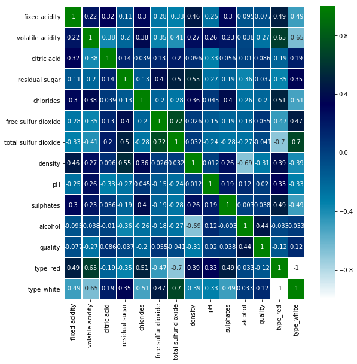

```python
import matplotlib.pyplot as plt
import seaborn as sns
plt.figure(figsize=(9, 9))
sns.heatmap(df0.corr(),linewidths=0.6,annot=True,cmap='ocean_r',cbar=True)
```

Look at the above figure, it is the correlation matrix for different attributes of all types wines. We can see the relation (positive or negative) between different attributions. For example, There is a significant positive relation between 'total sulfur dioxide' and 'free sulfur dioxide' (0.72); The amount of relation between wine type and other attributes has no difference, only positive and negative different; Alcohol can be a significant influence of quality (0.44), while other attributes may not have significant relation with quality.

#### Histogram plot

```
array([[<matplotlib.axes._subplots.AxesSubplot object at 0x7f0acc316208>]],
      dtype=object)
```

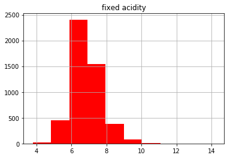

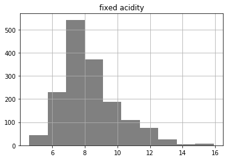

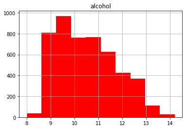

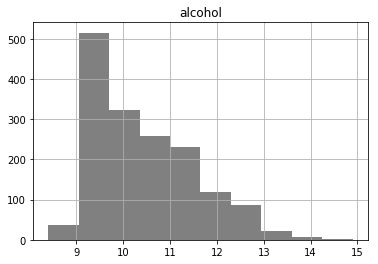

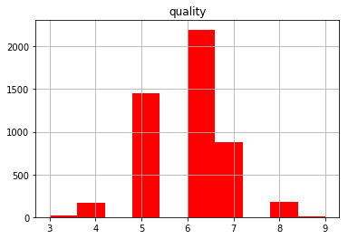

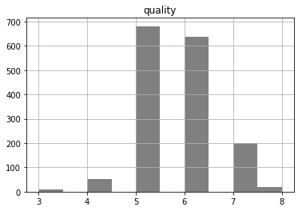

```python
import numpy as np
import pandas as pd
import matplotlib.pyplot as plt
df1.hist(column='fixed acidity', color='red') # red wine
df2.hist(column='fixed acidity', color='grey') # white wine
df1.hist(column='alcohol', color='red') # red wine
df2.hist(column='alcohol', color='grey') # white wine
df1.hist(column='quality', color='red') # red wine
df2.hist(column='quality', color='grey') # white wine
```

Above is the example histogram for 3 attributes of white and red wine. We can see the distribution of the data.

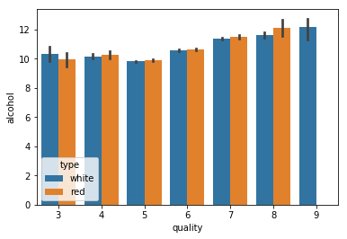

```python
# Barplot for quality vs alcohol
sns.barplot(x='quality', y = 'alcohol', hue = 'type' , data = df)
```

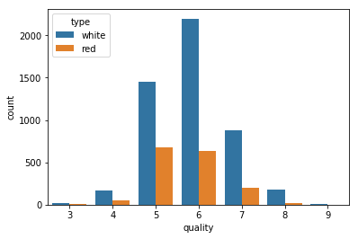

```python
# Countplot for Wine quality for both types
sns.countplot(x = df['quality'], data=df, hue='type')
```

#### Scatter plot

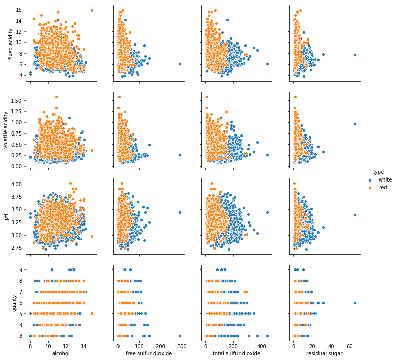

```python
sns.pairplot(df,hue='type',x_vars =
            ['alcohol','free sulfur dioxide', 'total sulfur dioxide','residual sugar'],
            y_vars = ['fixed acidity','volatile acidity','pH','quality'])
```

## Split Data

```python
from sklearn.model_selection import train_test_split
train_x, test_x, train_y, test_y = train_test_split(df0.drop('quality', axis=1), df0['quality'], test_size=0.2, random_state=42)
```

//use 0.2 test ratio, also pick a random number 42 as its internal state

```python
train_x.shape
```

```
(5197, 13)
```

```python
test_x.shape
```

```
(1300, 13)
```

```python
train_y.shape
```

```
(5197,)
```

```python
test_y.shape
```

```
(1300,)
```

## RandomForest (model, model0)

```python
from sklearn.ensemble import RandomForestClassifier

model = RandomForestClassifier(random_state=13)
model.fit(train_x, train_y)
```

```
RandomForestClassifier(bootstrap=True, class_weight=None, criterion='gini',
            max_depth=None, max_features='auto', max_leaf_nodes=None,
            min_impurity_decrease=0.0, min_impurity_split=None,
            min_samples_leaf=1, min_samples_split=2,
            min_weight_fraction_leaf=0.0, n_estimators=10, n_jobs=None,
            oob_score=False, random_state=13, verbose=0, warm_start=False)
```

```python
predicted = model.predict(test_x)
model.score(test_x, test_y)
```

```
0.6630769230769231
```

Notice the predict accuracy is not high (0.66), parameters tuning is required.

```python
from sklearn.model_selection import RandomizedSearchCV
criterion = ['gini', 'entropy']
class_weight = ['balanced', None]
# Number of trees in random forest
n_estimators = [int(x) for x in np.linspace(start = 200, stop = 2000, num = 10)]
# Number of features to consider at every split
max_features = ['auto', 'sqrt']
# Maximum number of levels in tree
max_depth = [int(x) for x in np.linspace(10, 110, num = 11)]
max_depth.append(None)
# Minimum number of samples required to split a node
min_samples_split = [2, 5, 10]
# Minimum number of samples required at each leaf node
min_samples_leaf = [1, 2, 4]
# Method of selecting samples for training each tree
bootstrap = [True, False]
# Create the random grid
random_grid = {'n_estimators': n_estimators,
               'max_features': max_features,
               'max_depth': max_depth,
               'min_samples_split': min_samples_split,
               'min_samples_leaf': min_samples_leaf,
               'bootstrap': bootstrap,
              'criterion': criterion,
              'class_weight': class_weight}
print(random_grid)
```

[output not shown]

Just skip next cell...(commented)

```python
def evaluate(model, test_features, test_labels):
    predictions = model.predict(test_features)
    errors = abs(predictions-test_labels)
    mape = 100 * np.mean(errors/test_labels)
    accuracy = 100 - mape
    print('Model Performance')
    print('Average Error: {:0.4f} degrees.'.format(np.mean(errors)))
    print('Accuracy = {:0.2f}%.'.format(accuracy))
    return accuracy

## Use the random grid to search for best hyperparameters
## First create the base model to tune
#rf = RandomForestClassifier()
## Random search of parameters, using 5 fold cross validation,
## search across 100 different combinations, and use all available cores
#rf_random = RandomizedSearchCV(estimator = rf, param_distributions = random_grid, n_iter = 100, cv = 5, verbose=2, random_state=42, n_jobs = -1)
## Fit the random search model
#rf_random.fit(train_x, train_y)
#params = rf_random.best_params_

#base_accuracy = evaluate(params, test_x, test_y)
#print(base_accuracy)
```

Unforturnately, the above step leads to "memory leak", thus I run it on local python, and the best parameteres are: {'n_estimators': 600, 'min_samples_split': 2, 'min_samples_leaf': 1, 'max_features': 'sqrt', 'max_depth': 30, 'criterion': 'entropy', 'class_weight': 'balanced', 'bootstrap': True}

```python
params = {'n_estimators': 600, 'min_samples_split': 2, 'min_samples_leaf': 1, 'max_features': 'sqrt',
          'max_depth': 30, 'bootstrap': True, 'criterion':'entropy', 'class_weight':'balanced'}
```

```python
model0 = RandomForestClassifier(bootstrap=True, class_weight='balanced', criterion='entropy',
            max_depth=30, max_features='sqrt', max_leaf_nodes=None,
            min_impurity_decrease=0.0, min_impurity_split=None,
            min_samples_leaf=1, min_samples_split=2,
            min_weight_fraction_leaf=0.0, n_estimators=600, n_jobs=None,
            oob_score=False, random_state=13, verbose=0, warm_start=False)
model0.fit(train_x, train_y)
predicted = model0.predict(test_x)
model0.score(test_x, test_y)
```

```
0.7046153846153846
```

Just a little bit better...

## Bayes (model 1)

```python
from sklearn.naive_bayes import MultinomialNB as mnb
model1 = mnb()
model1.fit(train_x, train_y)
```

```
MultinomialNB(alpha=1.0, class_prior=None, fit_prior=True)
```

```python
predicted = model1.predict(test_x)
model1.score(test_x, test_y)
```

```
0.3553846153846154
```

## SVM (model 2)

```python
from sklearn import svm
from sklearn.model_selection import GridSearchCV as gs
```

```python
def svc_param_selection(X, y, nfolds):
    Cs = [1000]
    gammas = [0.001, 0.01, 0.1, 1]
    degrees = [0]
    param_grid = {'C':Cs,'gamma': gammas,'degree':degrees}
    grid_search = gs(svm.SVC(kernel='sigmoid'), param_grid, cv=nfolds, verbose=2)
    grid_search.fit(X, y)
    return grid_search.best_params_
```

```python
parameters = svc_param_selection(train_x, train_y, 3) #return the best parameter of SVM
```

```
Fitting 3 folds for each of 4 candidates, totalling 12 fits
[CV] C=1000, degree=0, gamma=0.001 ...................................
```

```
[Parallel(n_jobs=1)]: Using backend SequentialBackend with 1 concurrent workers.
```

```
[CV] .................... C=1000, degree=0, gamma=0.001, total=   2.1s
[CV] C=1000, degree=0, gamma=0.001 ...................................
```

```
[Parallel(n_jobs=1)]: Done   1 out of   1 | elapsed:    3.3s remaining:    0.0s
```

[output not shown]

```
[Parallel(n_jobs=1)]: Done  12 out of  12 | elapsed:   32.3s finished
```

```python
for k, v in parameters.items():
    model2=svm.SVC().set_params(C=parameters['C'], gamma=parameters['gamma'])
    # print(clf)
    break
```

```python
model2.fit(train_x, train_y)
predicted = model2.predict(test_x)
model2.score(test_x, test_y)
```

```
0.5907692307692308
```

## Predict wine type

// Use all attributes except type to predict the type of wine...

```python
from sklearn.model_selection import train_test_split
train_x1, test_x1, train_y1, test_y1 = train_test_split(df0.drop(['type_white','type_red'], axis=1), df0['type_red'], test_size=0.2, random_state=42)
model0.fit(train_x1,train_y1)
predicted = model0.predict(test_x1)
model0.score(test_x1, test_y1)
```

```
0.9961538461538462
```

## Function for predict quality/type

```python
def predict_quality(f_acid, v_acid, c_acid, r_sugar, chlo, free_sulfur, total_sulfur, density, pH, sulphates,
                   alcohol, type1, type2):
    input = [{'fixed acidity': f_acid,
              'volatile acidity': v_acid,
              'citric acid': c_acid,
              'residual sugar': r_sugar,
              'chlorides': chlo,
              'free sulfur dioxide': free_sulfur,
              'total sulfur dioxide': total_sulfur,
              'density': density,
              'pH': pH,
              'sulphates': sulphates,
              'alcohol': alcohol,
              'type_white': type1,
              'type_red': type2}]
    return model0.predict(pd.DataFrame(input))[0]
```

```python
predict_quality(8.5, 0.32, 0.41, 8.8, 0.052, 38.0, 122.0, 0.9875, 3.3, 0.48,
                12.0, 0, 1)
# Predict quality with random variables...
```

[output not shown]

```python
predict_quality(8.5, 0.32, 0.41, 8.8, 0.052, 38.0, 122.0, 0.9875, 3.3, 0.48,
                12.0, 1, 0)
# Predict quality with random variables...
```

[output not shown]

```python
def predict_type(f_acid, v_acid, c_acid, r_sugar, chlo, free_sulfur, total_sulfur, density, pH, sulphates,
                   alcohol, quality):
    input = [{'fixed acidity': f_acid,
              'volatile acidity': v_acid,
              'citric acid': c_acid,
              'residual sugar': r_sugar,
              'chlorides': chlo,
              'free sulfur dioxide': free_sulfur,
              'total sulfur dioxide': total_sulfur,
              'density': density,
              'pH': pH,
              'sulphates': sulphates,
              'alcohol': alcohol,
              'quality': quality}]
    return model0.predict(pd.DataFrame(input))[0]
```

```python
predict_type(8.5, 0.32, 0.41, 8.8, 0.052, 38.0, 122.0, 0.9875, 3.3, 0.48,
                12.0, 7)
# Predict quality with random variables...
```

```
1
```

// As the output above shown, our best model (model0: the RandomForest one) predicts the type of the above wine is red (type_red = 1).

//Improvements could be done...

- Multicollinearity issue (not considered in this predict function, e.g. may not need all variables to predict?)
- Accuracy is not high.. (0.7) //I'm confused if an attribute of dataset can be well predicted by other atrributes.. (well-conditioned problem?)
- Not tuning other model (e.g. Bayes, kNN?)